# Uine’s IODS course project

**Part 2**

Here we implement the analyses of Chapter 9 of MABS using the BPRS (Brief Psychiatric Rating Scale) data. As with rats, this data is preorganized to long form from the original wide form.

First, let’s check the line plots for this data, both in raw and in standardized forms:

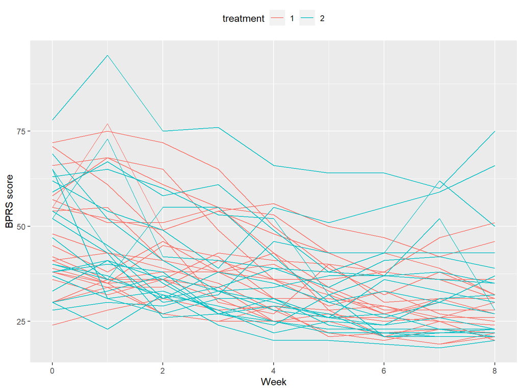

```r
# Plot of BPRS scores of subjects against time, colored by treatment group

ggplot(data_B, aes(x = week, y = bprs, group = id)) +
  geom_line(aes(col = treatment)) +
  scale_x_continuous(name = "Week") +
  scale_y_continuous(name = "BPRS score") +
  theme(legend.position = "top")
```

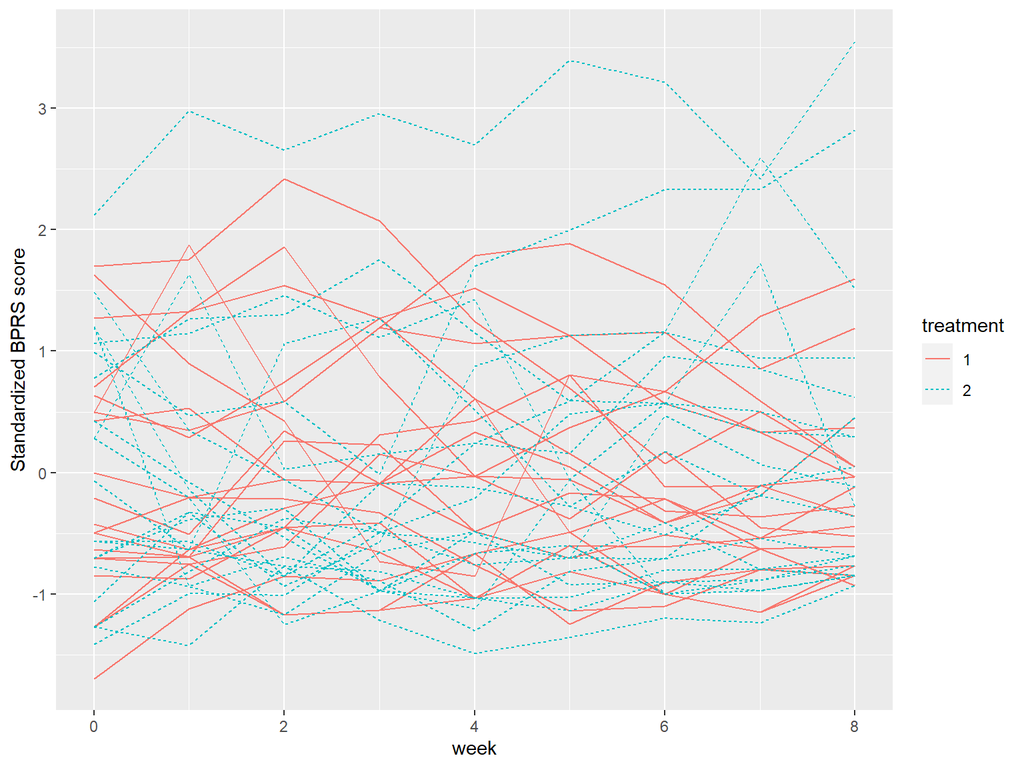

```r
# Standardizing the variable "bprs" to "bprs_std", plotting again

data_B <- data_B %>%
  group_by(week) %>%
  mutate(bprs_std = (bprs - mean(bprs))/sd(bprs) ) %>%
  ungroup()

ggplot(data_B, aes(x = week, y = bprs_std, group = id)) +
  geom_line(aes(col = treatment, linetype = treatment)) +
  scale_y_continuous(name = "Standardized BPRS score")
```

There seems to be slight decrease in BPRS results in both treatment groups, but these plots are not very clear to read or interpret. So, let’s fit regression model and series of random intercept models for performing multilevel linear regression model to our data!

```r
# Regression model
bprs_reg <- lm(bprs ~ week + treatment,
               data = data_B)

summary(bprs_reg)
```

```
##
## Call:
## lm(formula = bprs ~ week + treatment, data = data_B)
##
## Residuals:
##     Min      1Q  Median      3Q     Max
## -22.454  -8.965  -3.196   7.002  50.244
##
## Coefficients:
##             Estimate Std. Error t value Pr(>|t|)
## (Intercept)  46.4539     1.3670  33.982   <2e-16 ***
## week         -2.2704     0.2524  -8.995   <2e-16 ***
## treatment2    0.5722     1.3034   0.439    0.661
## ---
## Signif. codes:  0 '***' 0.001 '**' 0.01 '*' 0.05 '.' 0.1 ' ' 1
##
## Residual standard error: 12.37 on 357 degrees of freedom
## Multiple R-squared:  0.1851, Adjusted R-squared:  0.1806
## F-statistic: 40.55 on 2 and 357 DF,  p-value: < 2.2e-16
```

```r
# Random intercept model 1
bprs_ref1 <- lmer(bprs ~ week + treatment + (1 | id),
                 data = data_B, REML = FALSE)
summary(bprs_ref1)
```

```
## Linear mixed model fit by maximum likelihood  ['lmerMod']
## Formula: bprs ~ week + treatment + (1 | id)
##    Data: data_B
##
##      AIC      BIC   logLik deviance df.resid
##   2582.9   2602.3  -1286.5   2572.9      355
##
## Scaled residuals:
##      Min       1Q   Median       3Q      Max
## -2.27506 -0.59909 -0.06104  0.44226  3.15835
##
## Random effects:
##  Groups   Name        Variance Std.Dev.
##  id       (Intercept) 97.39    9.869
##  Residual             54.23    7.364
## Number of obs: 360, groups:  id, 40
##
## Fixed effects:
##             Estimate Std. Error t value
## (Intercept)  46.4539     2.3521  19.750
## week         -2.2704     0.1503 -15.104
## treatment2    0.5722     3.2159   0.178
##
## Correlation of Fixed Effects:
##            (Intr) week
## week       -0.256
## treatment2 -0.684  0.000
```

```r
# Random intercept model 2
bprs_ref2 <- lmer(bprs ~ week + treatment + (week | id),
                 data = data_B, REML = FALSE)
summary(bprs_ref2)
```

```
## Linear mixed model fit by maximum likelihood  ['lmerMod']
## Formula: bprs ~ week + treatment + (week | id)
##    Data: data_B
##
##      AIC      BIC   logLik deviance df.resid
##   2523.2   2550.4  -1254.6   2509.2      353
##
## Scaled residuals:
##     Min      1Q  Median      3Q     Max
## -2.4655 -0.5150 -0.0920  0.4347  3.7353
##
## Random effects:
##  Groups   Name        Variance Std.Dev. Corr
##  id       (Intercept) 167.827  12.955
##           week          2.331   1.527   -0.67
##  Residual              36.747   6.062
## Number of obs: 360, groups:  id, 40
##
## Fixed effects:
##             Estimate Std. Error t value
## (Intercept)  45.9830     2.6470  17.372
## week         -2.2704     0.2713  -8.370
## treatment2    1.5139     3.1392   0.482
##
## Correlation of Fixed Effects:
##            (Intr) week
## week       -0.545
## treatment2 -0.593  0.000
```

```r
# Random intercept model 2
bprs_ref3 <- lmer(bprs ~ week + treatment + treatment*week + (week | id),
                 data = data_B, REML = FALSE)
summary(bprs_ref3)
```

```
## Linear mixed model fit by maximum likelihood  ['lmerMod']
## Formula: bprs ~ week + treatment + treatment * week + (week | id)
##    Data: data_B
##
##      AIC      BIC   logLik deviance df.resid
##   2523.5   2554.5  -1253.7   2507.5      352
##
## Scaled residuals:
##     Min      1Q  Median      3Q     Max
## -2.4747 -0.5256 -0.0866  0.4435  3.7884
##
## Random effects:
##  Groups   Name        Variance Std.Dev. Corr
##  id       (Intercept) 164.204  12.814
##           week          2.203   1.484   -0.66
##  Residual              36.748   6.062
## Number of obs: 360, groups:  id, 40
##
## Fixed effects:
##                 Estimate Std. Error t value
## (Intercept)      47.8856     2.9840  16.047
## week             -2.6283     0.3752  -7.006
## treatment2       -2.2911     4.2200  -0.543
## week:treatment2   0.7158     0.5306   1.349
##
## Correlation of Fixed Effects:
##             (Intr) week   trtmn2
## week        -0.668
## treatment2  -0.707  0.473
## wek:trtmnt2  0.473 -0.707 -0.668
```

From the models abow we can see that only the variant “week” seems to be significant contributor to improvements in the BPRS. Treatment doesn’t explain differences between individuals. In the last random intercept model (bprs_ref3) we explore if the effect of treatment is indeed dependent on time by adding term "treatment*week".

There is 47 % correlation between “treatment 2” and “week” - let’s see how analysis of variance table looks like between “bprs_ref1” & “bprs_ref2”, and “bprs_ref2” & “bprs_ref3”.

```r
# ANOVA test on the models
anova(bprs_ref1,bprs_ref2)
```

```
## Data: data_B
## Models:
## bprs_ref1: bprs ~ week + treatment + (1 | id)
## bprs_ref2: bprs ~ week + treatment + (week | id)
##           npar    AIC    BIC  logLik deviance  Chisq Df Pr(>Chisq)
## bprs_ref1    5 2582.9 2602.3 -1286.5   2572.9
## bprs_ref2    7 2523.2 2550.4 -1254.6   2509.2 63.663  2  1.499e-14 ***
## ---
## Signif. codes:  0 '***' 0.001 '**' 0.01 '*' 0.05 '.' 0.1 ' ' 1
```

```r
anova(bprs_ref2,bprs_ref3)
```

```
## Data: data_B
## Models:
## bprs_ref2: bprs ~ week + treatment + (week | id)
## bprs_ref3: bprs ~ week + treatment + treatment * week + (week | id)
##           npar    AIC    BIC  logLik deviance Chisq Df Pr(>Chisq)
## bprs_ref2    7 2523.2 2550.4 -1254.6   2509.2
## bprs_ref3    8 2523.5 2554.6 -1253.7   2507.5  1.78  1     0.1821
```

According to Pr(>Chisq) values, the bprs_ref1,bprs_ref2 pair performed better than bprs_ref2,bprs_ref3 pair. Let’s visualize our bprs_ref2 model for comparison to the original raw data line charts:

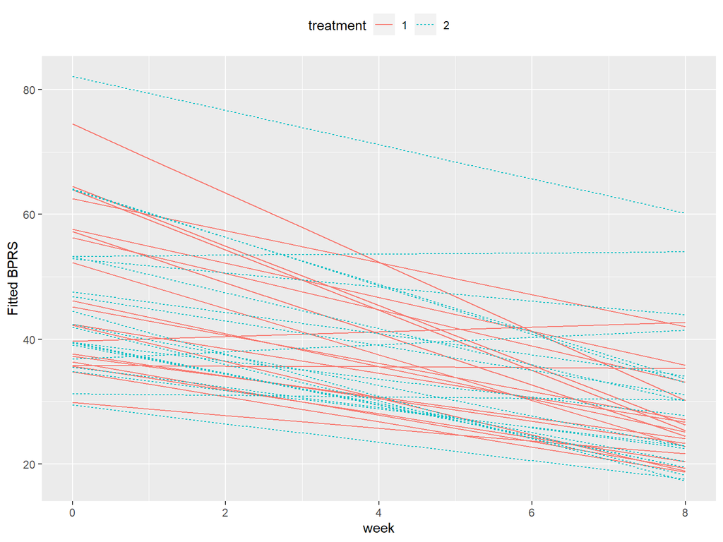

```r
# Visualization of random intercept model "bprs_ref2"
data_B$fitted2 <- fitted(bprs_ref2)

ggplot(data_B, aes(x = week, y = fitted2, group = id)) +
  geom_line(aes(col = treatment, linetype = treatment)) +
  scale_y_continuous(name = "Fitted BPRS") +
  theme(legend.position = "top")
```

The chart is much easier to interpret than the messy zig zag raw data, and the model seems to perfom pretty well. We can see that BPRS scores decrease in both groups with passing time, but there are no clear differences between treatment groups.

There we have it! Happy holidays, fellow course participants :)